# Problem Set 02

Due Friday, September 30, 2016

```r
# Do not edit this section
library(ggplot2)
library(dplyr)
library(ggplot2movies)
library(babynames)
```

## Question 1: Movie Ratings

```r
data(movies)
movies <- movies %>%
  sample_n(1000) %>%
  mutate(Comedy=ifelse(Comedy==1, "yes", "no"))
```

#### a)

You want to know for these 1000 randomly chosen movies: What is the relationship between the year the movie was made and the IMDB rating? Furthermore, I want to distinguish between comedies and non-comedies. In the code block below, write the code that generates a graphic that will answer this for you:

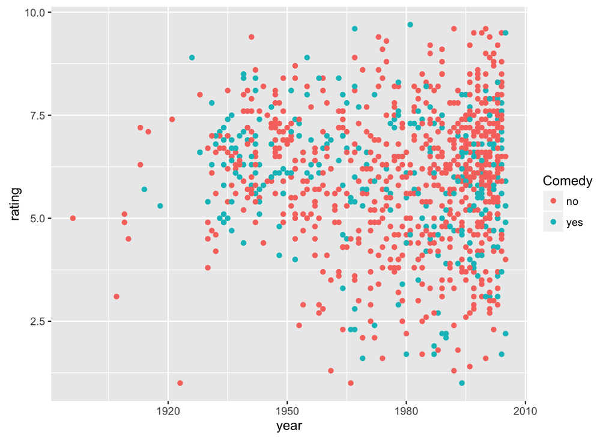

```r
ggplot(data=movies, aes(x=year, y=rating, col=Comedy)) +
  geom_point()
```

#### b)

As best you can, answer this question: Within these 1000 movies, do comedies get rated higher than non-comedies?

We add a regression line for Comedies and Non-Comedies

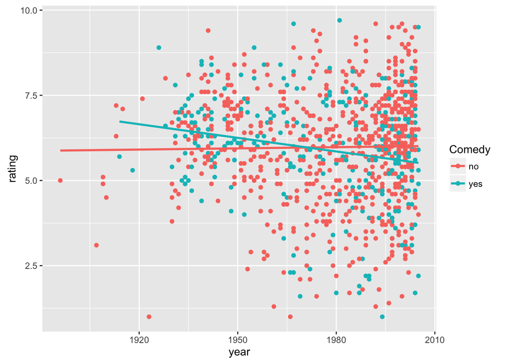

```r
ggplot(data=movies, aes(x=year, y=rating, col=Comedy)) +
  geom_point() +
  geom_smooth(method="lm", se=FALSE)
```

Is that small difference **statistically significant**? Hard to tell.

## Question 2: Babynames

Considering the `babynames` data set in the `babynames` package again, we will limit consideration to only the name “Casey”.

```r
data(babynames)
babynames <- babynames %>%
  filter(name=="Casey")
```

#### a)

I want to know about popularity trends of the name “Casey” as a male name and as a female name over the years. In the code block below, write the code that generates a graphic that will answer this for you:

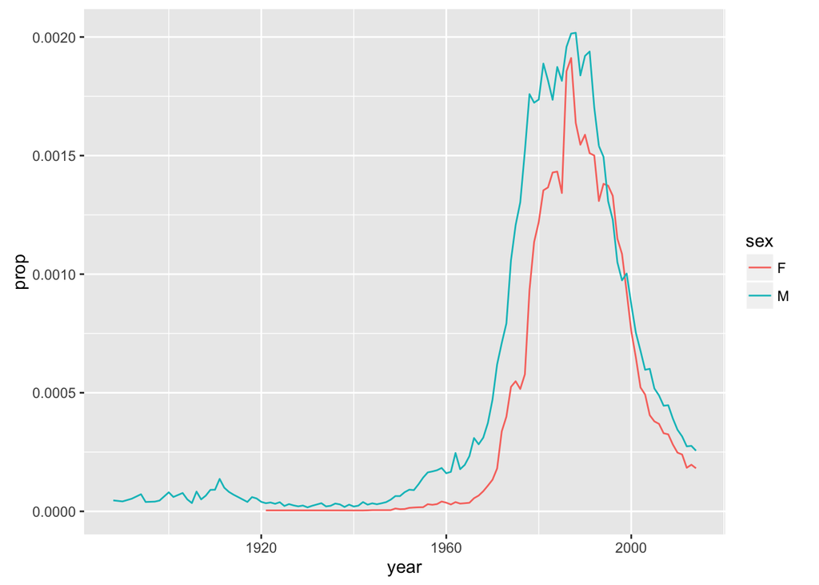

```r
ggplot(data=babynames, aes(x=year, y=prop, col=sex)) +
  geom_line()
```

#### b)

Given this graphic, what can you say about the name “Casey”? Don’t merely describe what is already apparent on the graphic, but make a broader statement.